# HDAT9600 Final Team Assignment

Please see course timetable / ‘Announcements’ for submission deadline

Team 3: Zhenyu

## Instructions

- This file (hdat9600assess4_teamX.Rmd) is the R Markdown document in which you need to complete your HDAT9600 final team assignment.
- You should rename the file by replacing ‘X’ with your team number.
- This assignment is assessed and will count for 30% of the total course marks.
- The assignment comprises two tasks. The first task will focus on building a model to PREDICT an outcome and the second task will focus on using a model to EXPLAIN the relationships between a variable of interest and the outcome.
- There is no word limit, nor limit on the length of your submitted Rmarkdown (i.e. this file) document. However, the **rendered** html document, were it to be printed, should be **no more** than about 10 A4 pages in length.
- Your html rendered document should include sufficient code chunks, output, and visual display as necessary to support your discursive commentary addressing each task. You may therefore wish to **suppress some of the contents** of your Rmarkdown file from appearing within the rendered document to ensure your output focuses on the most relevant results and discussion to address the questions.
- The rendered (html) document will be the submission primarily considered when awarding credit. However, the Rmarkdown file may also be considered if required to understand the analysis.
- **Excessively long reports will be penalised** by cessation of awarding of credit after roughly 10 pages of content.
- Feel free to delete the assignment instructions as you see fit to allow you some more room.
- All tasks are intended to be completed as a team. Have fun discussing the tasks and working together.

Don’t hesitate to ask the course convenor for help via OpenLearning. The course instructor is happy to point you in the right direction and to make suggestions, but they won’t, of course, complete your assessment for you!

## Data for this assessment

The data used for this assessment consist of records from Intensive Care Unit (ICU) hospital stays in the USA. All patients were adults who were admitted for a wide variety of reasons. ICU stays of less than 48 hours have been excluded.

The source data for the assessment are data made freely available for the 2012 MIT PhysioNet/Computing for Cardiology Challenge. Details are provided [here](https://physionet.org/challenge/2012/). Training Set A data have been used. The original data has been modified and assembled to suit the purpose of this assessment.

The dataframe consists of 120 variables, which are defined as follows:

#### Patient Descriptor Variables

*RecordID:* a unique integer for each ICU stay

*Age:* years

*Gender:* male/female

*Height:* cm

*ICUType:* Coronary Care Unit; Cardiac Surgery Recovery Unit; Medical ICU; Surgical ICU

*Length_of_stay:* The number of days between the patient’s admission to the ICU and the end of hospitalisation

*Survival:* The number of days between ICU admission and death for patients who died

#### Outcome Variables

*in_hospital_death:* 0:survivor/1:died in-hospital **this is the outcome variable for Task 1: Logistic Regression**

*Status:* True/False **this is the censoring variable for Task 2: Survival Analysis**

*Days:* Length of survival (in days) **this is the survival time variable for Task 2: Survival Analysis**

#### Clinical Variables

*Use the hyperlinks below to find out more about the clinical meaning of each variable.* The first two clinical variables are summary scores that are used to assess patient condition and risk.

- SAPS-I score - Simplified Acute Physiological Score [Le Gall et al., 1984](http://www.ncbi.nlm.nih.gov/pubmed/6499483)
- SOFA score - Sequential Organ Failure Assessment [Ferreira et al., 2001](http://www.ncbi.nlm.nih.gov/pubmed/11594901)

The following 36 clinical measures were assessed at multiple timepoints during each patient’s ICU stay. For each of the 36 clinical measures, you are given 3 summary variables: a) The minimum value during the first 24 hours in ICU (_min), b) The maximum value during the first 24 hours in ICU (_max), and c) The difference between the mean and the most extreme values during the first 24 hours in ICU (_diff). For example, for the clinical measure Cholesterol, these three variables are labelled ‘Cholesterol_min’, ‘Cholesterol_max’, and ‘Cholesterol_diff’.

- [Albumin](http://en.wikipedia.org/wiki/Human_serum_albumin) (g/dL)
- [ALP](http://en.wikipedia.org/wiki/Alkaline_phosphatase) [Alkaline phosphatase (IU/L)]
- [ALT](http://en.wikipedia.org/wiki/Alanine_transaminase) [Alanine transaminase (IU/L)]
- [AST](http://en.wikipedia.org/wiki/Aspartate_transaminase) [Aspartate transaminase (IU/L)]
- Bilirubin (mg/dL)
- BUN [Blood urea nitrogen (mg/dL)]
- Cholesterol (mg/dL)
- [Creatinine](http://en.wikipedia.org/wiki/Serum_creatinine#Plasma_creatinine) [Serum creatinine (mg/dL)]
- [DiasABP](http://en.wikipedia.org/wiki/Diastolic_blood_pressure) [Invasive diastolic arterial blood pressure (mmHg)]
- [FiO2](http://en.wikipedia.org/wiki/FIO2) [Fractional inspired O<sub>2</sub> (0-1)]
- [GCS](http://en.wikipedia.org/wiki/Glasgow_coma_score) [Glasgow Coma Score (3-15)]
- [Glucose](http://en.wikipedia.org/wiki/Serum_glucose) [Serum glucose (mg/dL)]
- [HCO3](http://en.wikipedia.org/wiki/Bicarbonate#Diagnostics) [Serum bicarbonate (mmol/L)]
- [HCT](http://en.wikipedia.org/wiki/Hematocrit) [Hematocrit (%)]
- [HR](http://en.wikipedia.org/wiki/Heart_rate) [Heart rate (bpm)]
- [K](http://en.wikipedia.org/wiki/Hypokalemia) [Serum potassium (mEq/L)]
- [Lactate](http://en.wikipedia.org/wiki/Lactic_acid) (mmol/L)
- [Mg](http://en.wikipedia.org/wiki/Magnesium#Biological_role) [Serum magnesium (mmol/L)]
- [MAP](http://en.wikipedia.org/wiki/Mean_arterial_pressure) [Invasive mean arterial blood pressure (mmHg)]
- [MechVent](http://en.wikipedia.org/wiki/Mechanical_ventilation) [Mechanical ventilation respiration (0:false, or 1:true)]
- [Na](http://en.wikipedia.org/wiki/Serum_sodium) [Serum sodium (mEq/L)]
- [NIDiasABP](http://en.wikipedia.org/wiki/Diastolic_blood_pressure) [Non-invasive diastolic arterial blood pressure (mmHg)]
- [NIMAP](http://en.wikipedia.org/wiki/Mean_arterial_pressure) [Non-invasive mean arterial blood pressure (mmHg)]
- [NISysABP](http://en.wikipedia.org/wiki/Systolic_blood_pressure) [Non-invasive systolic arterial blood pressure (mmHg)]
- [PaCO2](http://en.wikipedia.org/wiki/Arterial_blood_gas) [partial pressure of arterial CO<sub>2</sub> (mmHg)]
- [PaO2](http://en.wikipedia.org/wiki/Arterial_blood_gas) [Partial pressure of arterial O<sub>2</sub> (mmHg)]
- [pH](http://en.wikipedia.org/wiki/Arterial_blood_gas) [Arterial pH (0-14)]
- Platelets (cells/nL)
- [RespRate](http://en.wikipedia.org/wiki/Respiratory_physiology) [Respiration rate (bpm)]
- [SaO2](http://en.wikipedia.org/wiki/Arterial_blood_gas) [O<sub>2</sub> saturation in hemoglobin (%)]
- [SysABP](http://en.wikipedia.org/wiki/Systolic_blood_pressure) [Invasive systolic arterial blood pressure (mmHg)]
- [Temp](http://en.wikipedia.org/wiki/Normal_human_body_temperature) [Temperature (°C)]
- [TropI](http://en.wikipedia.org/wiki/Troponin) [Troponin-I (μg/L)]
- [TropT](http://en.wikipedia.org/wiki/Troponin) [Troponin-T (μg/L)]
- [Urine](http://en.wikipedia.org/wiki/Fluid_balance) [Urine output (mL)]
- [WBC](http://en.wikipedia.org/wiki/Reference_ranges_for_blood_tests#Hematology) [White blood cell count (cells/nL)]
- Weight (kg)

## Accessing the Data

There are two datasets provided. The data frames can be loaded with the following code:

```r
mydat <- file.path("C:/Users/froze/OneDrive/Documents/2.1 UNSW bioinfo/HDAT9600/Assignment/Group/HDAT9600_Assign4_GroupProject")
icu_patients_df0 <- readRDS(file.path(mydat,"icu_patients_df0.rds"))
icu_patients_df1 <- readRDS(file.path(mydat,"icu_patients_df1.rds"))

#summary(icu_patients_df1) #useful for initial checks
#str(icu_patients_df1) # Structure of the dataset
#glimpse(icu_patients_df1) #quickly see the entirety of the data frame's structure and less likely to truncate
length(unique(icu_patients_df1$RecordID)) # Unique patient check
```

```
## [1] 2061
```

```r
# Calculate the number of missing values for each column
missing_values <- colSums(is.na(icu_patients_df1))
# Remove the variables that do not have missing values
missing_values <- missing_values[missing_values > 0]
# Print the variables with their count of missing values
print(missing_values)
```

```
##          SAPS1       Survival   DiasABP_diff    DiasABP_max    DiasABP_min
##             96           1288            715            715            715
##         Height NIDiasABP_diff  NIDiasABP_max  NIDiasABP_min     NIMAP_diff
##            992            455            455            455            455
##      NIMAP_max      NIMAP_min  NISysABP_diff   NISysABP_max   NISysABP_min
##            455            455            453            453            453
##    SysABP_diff     SysABP_max     SysABP_min    Weight_diff     Weight_max
##            715            715            715            146            146
##     Weight_min
##            146
```

**Note:** icu_patients_df1 is an imputed (i.e. missing values are ‘derived’) version of icu_patients_df0. This assessment does not concern the methods used for imputation. You should use `icu_patients_df1` for all tasks unless it is specifically noted to use `icu_patients_df0`.

From the output and combined with reference papers, here are some variables that correspond to the SAPS-I and SOFA scores and could be considered important for the models: 1. **SAPS-I score**: The dataset includes SAPS1 as a variable, which is directly relevant. 2. **SOFA score**: The dataset includes SOFA as a variable, also directly relevant. 3. **Respiratory function**: PaO2/FiO2 ratio (part of SOFA), and Respiratory rate (part of SAPS-I). In the dataset, PaO2, FiO2 and RespRate variables could be related to respiratory function (not find MechVent variable). 4. **Coagulation**: Platelets count is directly mentioned in the dataset and SOFA. 5. **Liver function**: Bilirubin levels are included in both the dataset and the SOFA score. 6. **Cardiovascular system**: The presence of hypotension and administration of dopamine or dobutamine are factors in the SOFA score. In the dataset, variables like MAP, SysABP, and NIMAP are related to blood pressure and might be used as proxies. 7. **Central nervous system**: Glasgow Coma Score is present in both the SOFA and SAPS-I scores and directly available in the dataset (GCS variables). 8. **Renal function**: Creatinine levels and Urine output, which are in SOFA and indirectly in SAPS-I (blood urea), correspond to Creatinine and Urine variables in the data. 9. **Age**: This is explicitly mentioned in SAPS-I and is a known risk factor in ICU outcomes. The Age variable is available in the dataset.

Considering these variables for inclusion in the predictive models for Task 1 (Logistic Regression for in-hospital death) and Task 2 (Survival Analysis for length of survival) would be reasonable based on their clinical importance and representation in established severity scores.

**values outside of plausible clinical ranges or logically incorrect** - `SOFA` should not be negative Convert to integers and replace negative values with NA. - `Length_of_stay` should not be negative (they are all -1 and not +1 in data set) Convert to positive - `Weight` absurd weight differences and extremely high values

```r
# Initial type conversions and handling of illogical variables
icu_patients_df1_conv <- icu_patients_df1 %>%
  mutate(
    SAPS1 = if_else(SAPS1 < 0, NA_real_, as.integer(SAPS1)),
    SOFA = if_else(SOFA < 0, NA_real_, as.integer(SOFA)),
    Length_of_stay = if_else(Length_of_stay < 0, abs(Length_of_stay), Length_of_stay),
    Age = as.integer(Age),
    GCS_max = as.integer(GCS_max),
    Gender = as.factor(Gender),
    ICUType = as.factor(ICUType),
    Status_Label = factor(Status, levels = c(FALSE, TRUE), labels = c("Survived", "Died")),
    LR_in_hospital_death = factor(in_hospital_death, levels = c(0, 1), labels = c("Survived", "Died"))
  )


# Set a threshold for maximum acceptable proportion of missing data
missing_threshold <- 0.3
# Calculate the proportion of missing data for each variable
prop_missing <- colSums(is.na(icu_patients_df1_conv)) / nrow(icu_patients_df1_conv)
# Identify variables to exclude based on the threshold
vars_to_check <- setdiff(names(icu_patients_df1_conv), "Survival") # Exclude the 'Survival' variable from the evaluation for missing data
vars_to_exclude <- names(prop_missing[vars_to_check][prop_missing[vars_to_check] > missing_threshold])
print("Variables to be excluded due to high missing data:")
```

```
## [1] "Variables to be excluded due to high missing data:"
```

```r
print(vars_to_exclude)
```

```
## [1] "DiasABP_diff" "DiasABP_max"  "DiasABP_min"  "Height"       "SysABP_diff"
## [6] "SysABP_max"   "SysABP_min"
```

```r
# Identify variables to impute
vars_to_impute <- names(prop_missing[prop_missing <= missing_threshold & prop_missing > 0])
# Make a copy of the data frame to clean
icu_patients_df1_cleaned <- icu_patients_df1_conv
# Impute missing values for selected variables using median
for(var in vars_to_impute) {
  icu_patients_df1_cleaned[[var]][is.na(icu_patients_df1_cleaned[[var]])] <- median(icu_patients_df1_cleaned[[var]], na.rm = TRUE)
}
# Now exclude the variables with too much missing data from the cleaned dataframe
icu_patients_df1_cleaned <- icu_patients_df1_cleaned[ , !(names(icu_patients_df1_cleaned) %in% vars_to_exclude)]

# Check if there are any remaining missing values
missing_values <- colSums(is.na(icu_patients_df1_cleaned))
missing_values <- missing_values[missing_values > 0]
print("Remaining missing values in the cleaned data:")
```

```
## [1] "Remaining missing values in the cleaned data:"
```

```r
print(missing_values)
```

```
## Survival
##     1288
```

```r
# Print the number of observations after cleaning
print(paste("Number of observations after cleaning:", nrow(icu_patients_df1_cleaned)))
```

```
## [1] "Number of observations after cleaning: 2061"
```

## Aims of your project

You have two analytic goals in this assignment. 1. The first goal (Task 1) is to build a model to PREDICT in-hospital death. The context for this is that the hospital management wishes to use this model to prioritise the allocation of resources with the overarching aim of improving patient survival.  
2. The second goal (Task 2) is to try to understand and EXPLAIN how survival varies by `Age`. How does survival change with increasing Age? Are age-related survival differences explained solely by differing clinical characteristics of patients?

# Task 1

### Part A: Exploratory data analysis

Conduct a brief EDA for the dataset `icu_patients_df1`. One of your goals for this EDA should be to identify a sub-set of variables (approx 15-20 variables) that *may* be useful predictors of survival and/or relevant to your analytical task. You may wish to firstly undertake a brief literature review to try to identify factors that may be important predictors of survival in an ICU. This doesn’t need to be in-depth, but enough to get a basic idea of what the variables are measuring and which variables might, in theory, be most important.

For the 15-20 chosen variables, present enough information to: (i) explain why you selected these variables, based on a combination of your literature review and EDA, and (ii) Provide an overview of the variables and how they are related to `in-hospital death`. Present your summary using tables and/or plots with supporting commentary where relevant.

```r
# Overall Demographics Summary
overall_demo <- summary(icu_patients_df1[c("Age", "Height", "Weight_max", "Weight_min", "SOFA", "SAPS1")])
kable(overall_demo, caption = "Overall Demographics Summary", format = "markdown")
```

Overall Demographics Summary

|  | Age | Height | Weight_max | Weight_min | SOFA | SAPS1 |
| --- | --- | --- | --- | --- | --- | --- |
|  | Min. :16.00 | Min. : 13.0 | Min. : 34.60 | Min. : 34.60 | Min. :-1.000 | Min. : 1.00 |
|  | 1st Qu.:52.00 | 1st Qu.:162.6 | 1st Qu.: 66.00 | 1st Qu.: 65.00 | 1st Qu.: 3.000 | 1st Qu.:11.00 |
|  | Median :67.00 | Median :170.2 | Median : 80.00 | Median : 77.70 | Median : 6.000 | Median :15.00 |
|  | Mean :64.41 | Mean :170.0 | Mean : 82.66 | Mean : 80.86 | Mean : 6.441 | Mean :14.96 |
|  | 3rd Qu.:78.00 | 3rd Qu.:177.8 | 3rd Qu.: 94.55 | 3rd Qu.: 91.95 | 3rd Qu.: 9.000 | 3rd Qu.:19.00 |
|  | Max. :90.00 | Max. :426.7 | Max. :230.00 | Max. :230.00 | Max. :22.000 | Max. :34.00 |
|  | NA | NA’s :992 | NA’s :146 | NA’s :146 | NA | NA’s :96 |

```r
# Split the dataset into survivors and non-survivors
survivors_df <- icu_patients_df1[icu_patients_df1$in_hospital_death == 0, ]
deceased_df <- icu_patients_df1[icu_patients_df1$in_hospital_death == 1, ]

# Summary for Survivors
survivors_demo <- summary(survivors_df[c("Age", "Weight_max", "Weight_min", "Length_of_stay", "SOFA", "SAPS1")])
kable(survivors_demo, caption = "Demographics Summary for Survivors", format = "markdown")
```

Demographics Summary for Survivors

|  | Age | Weight_max | Weight_min | Length_of_stay | SOFA | SAPS1 |
| --- | --- | --- | --- | --- | --- | --- |
|  | Min. :16.00 | Min. : 34.60 | Min. : 34.60 | Min. : -1.00 | Min. :-1.000 | Min. : 1.00 |
|  | 1st Qu.:51.00 | 1st Qu.: 66.50 | 1st Qu.: 65.00 | 1st Qu.: 6.00 | 1st Qu.: 3.000 | 1st Qu.:11.00 |
|  | Median :66.00 | Median : 80.35 | Median : 78.50 | Median : 10.00 | Median : 6.000 | Median :15.00 |
|  | Mean :63.29 | Mean : 83.14 | Mean : 81.24 | Mean : 13.55 | Mean : 6.074 | Mean :14.49 |
|  | 3rd Qu.:78.00 | 3rd Qu.: 94.83 | 3rd Qu.: 92.00 | 3rd Qu.: 17.00 | 3rd Qu.: 9.000 | 3rd Qu.:18.00 |
|  | Max. :90.00 | Max. :230.00 | Max. :230.00 | Max. :154.00 | Max. :18.000 | Max. :34.00 |
|  | NA | NA’s :132 | NA’s :132 | NA | NA | NA’s :84 |

```r
# Summary for Non-Survivors
deceased_demo <- summary(deceased_df[c("Age", "Weight_max", "Weight_min", "Length_of_stay", "Survival", "SOFA", "SAPS1")])
kable(deceased_demo, caption = "Demographics Summary for Non-Survivors", format = "markdown")
```

Demographics Summary for Non-Survivors

|  | Age | Weight_max | Weight_min | Length_of_stay | Survival | SOFA | SAPS1 |
| --- | --- | --- | --- | --- | --- | --- | --- |
|  | Min. :22.00 | Min. : 35.00 | Min. : 35.00 | Min. : 2.00 | Min. : 1.00 | Min. :-1.00 | Min. : 3.00 |
|  | 1st Qu.:62.00 | 1st Qu.: 62.85 | 1st Qu.: 62.35 | 1st Qu.: 6.00 | 1st Qu.: 4.00 | 1st Qu.: 5.00 | 1st Qu.:14.00 |
|  | Median :76.00 | Median : 76.00 | Median : 74.60 | Median : 10.00 | Median : 8.00 | Median : 8.00 | Median :18.00 |
|  | Mean :71.05 | Mean : 79.88 | Mean : 78.65 | Mean : 14.89 | Mean : 11.85 | Mean : 8.62 | Mean :17.72 |
|  | 3rd Qu.:83.00 | 3rd Qu.: 93.15 | 3rd Qu.: 90.65 | 3rd Qu.: 17.00 | 3rd Qu.: 15.00 | 3rd Qu.:12.00 | 3rd Qu.:21.00 |
|  | Max. :90.00 | Max. :165.00 | Max. :165.00 | Max. :146.00 | Max. :145.00 | Max. :22.00 | Max. :33.00 |
|  | NA | NA’s :14 | NA’s :14 | NA | NA | NA | NA’s :12 |

```r
# Create a table for Gender Distribution, Number of in hospital Deaths, and ICU Types
# Calculate the required numbers and percentages
patients_count <- nrow(icu_patients_df1)
gender_counts <- table(icu_patients_df1$Gender)
gender_percentages <- prop.table(gender_counts) * 100
death_counts <- sum(icu_patients_df1$in_hospital_death, na.rm = TRUE)
death_percentage <- (death_counts / patients_count) * 100
icu_type_counts <- table(icu_patients_df1$ICUType)
icu_type_percentages <- prop.table(icu_type_counts) * 100

# Create a data frame with the calculated values
demographics_table <- data.frame(
  Category = c("Number_of_Patients",
               "Gender: Male",
               "Gender: Female",
               "in_hospital_death",
               "ICU Types: Coronary Care Unit",
               "ICU Types: Cardiac Surgery Recovery Unit",
               "ICU Types: Medical ICU",
               "ICU Types: Surgical ICU"),
  Number = c(patients_count,
             gender_counts["Male"],
             gender_counts["Female"],
             death_counts,
             icu_type_counts["Coronary Care Unit"],
             icu_type_counts["Cardiac Surgery Recovery Unit"],
             icu_type_counts["Medical ICU"],
             icu_type_counts["Surgical ICU"]),
  Percentage = c(NA,  # Placeholder for total patients percentage
                 gender_percentages["Male"],
                 gender_percentages["Female"],
                 death_percentage,
                 icu_type_percentages["Coronary Care Unit"],
                 icu_type_percentages["Cardiac Surgery Recovery Unit"],
                 icu_type_percentages["Medical ICU"],
                 icu_type_percentages["Surgical ICU"])
)

# Use kable to print the table
kable(demographics_table, caption = "Demographics Summary 2", align = c('l', 'r', 'r'), format = "markdown")
```

Demographics Summary 2

| Category | Number | Percentage |
| --- | --- | --- |
| Number_of_Patients | 2061 | NA |
| Gender: Male | 1148 | 55.70112 |
| Gender: Female | 913 | 44.29888 |
| in_hospital_death | 297 | 14.41048 |
| ICU Types: Coronary Care Unit | 297 | 14.41048 |
| ICU Types: Cardiac Surgery Recovery Unit | 448 | 21.73702 |
| ICU Types: Medical ICU | 788 | 38.23387 |
| ICU Types: Surgical ICU | 528 | 25.61863 |

**Overall Demographics Summary:** - Patients range in age from 16 to 90, with a median age of 67, suggesting a predominantly older patient population. - Height varies widely, with some extreme values (min 13 cm, max 426.7 cm), indicating possible data entry errors, given the maximum height is biologically implausible. - The max weight of patients (Weight_max) and minimum weight (Weight_min) during the stay are similar in range, indicating relatively stable weight during ICU stay or uniformity in recording practices. - SOFA scores, which range from -1 to 22, with a mean of 6.441, indicate varying degrees of organ failure severity among patients. - SAPS1 scores also show a wide range, but there are missing values for SAPS1 that may need addressing for complete analysis.

**Demographics Summary for Survivors and Non-Survivors:** - Survivors have a slightly lower mean age (63.29) compared to the overall (64.41) and non-survivor (71.05) groups, and the length of stay varies from -1 (which could be an error) to 154 days. - A small number of survivors have maximum and minimum weights at the upper limit of 230 kg, which may be outliers or may represent a small subset of critically ill patients with a higher body weight. - The median and mean weights for non-survivors are slightly lower than for survivors, which could reflect severe illness trajectories that may affects body weight. However, in general, the distribution of weight data does not indicate dramatic differences between survivors and non-survivors. - The median and average SOFA and SAPS1 scores among survivors is lower than non-survivors, which aligns with the understanding that higher scores are associated with more severe organ dysfunction and a higher likelihood of mortality.

**Demographics Table Summary 2:** - There were 2061 patients in total, with a higher proportion of males (approximately 55.70%) compared to females. - The proportion of patients who died in the hospital was about 14.41%. - The distribution of patients across ICU types shows the largest number in the Medical ICU (38.23%) and the least in the Coronary Care Unit (14.41%).

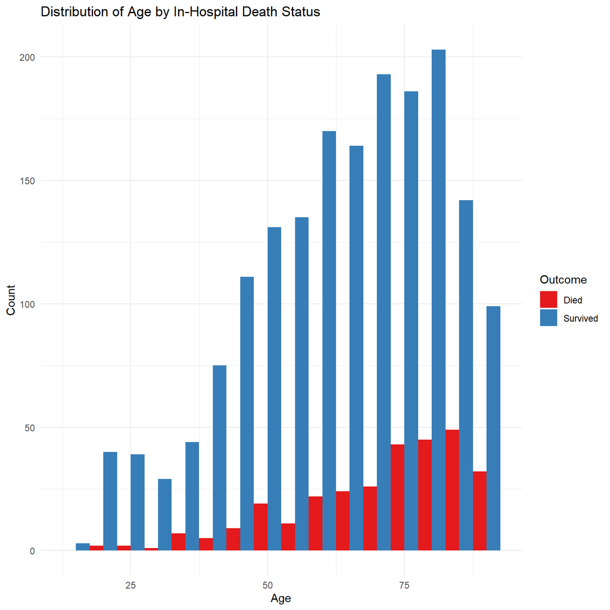

```r
# Add a descriptive label for in-hospital death status
icu_patients_df1$Status_Label <- ifelse(icu_patients_df1$in_hospital_death == 0, "Survived", "Died")
icu_patients_df1$Status_Label <- as.factor(icu_patients_df1$Status_Label)

# Create a list of demographic variables to plot
demographic_vars <- c("Age", "Height", "Weight_max", "Weight_min", "Length_of_stay", "Survival")

# Create a series of plots for each demographic variable
plots <- lapply(demographic_vars, function(var) {
  ggplot(icu_patients_df1, aes_string(x = var, fill = "Status_Label")) +
    geom_histogram(position = "dodge", binwidth = 5, na.rm = TRUE) +
    labs(x = var, y = "Count") +
    scale_fill_brewer(palette = "Set1", name = "Outcome") +
    theme_minimal() +
    ggtitle(paste("Distribution of", var, "by In-Hospital Death Status"))
})
# Print the plots
print(plots[[1]]) # For Age
```

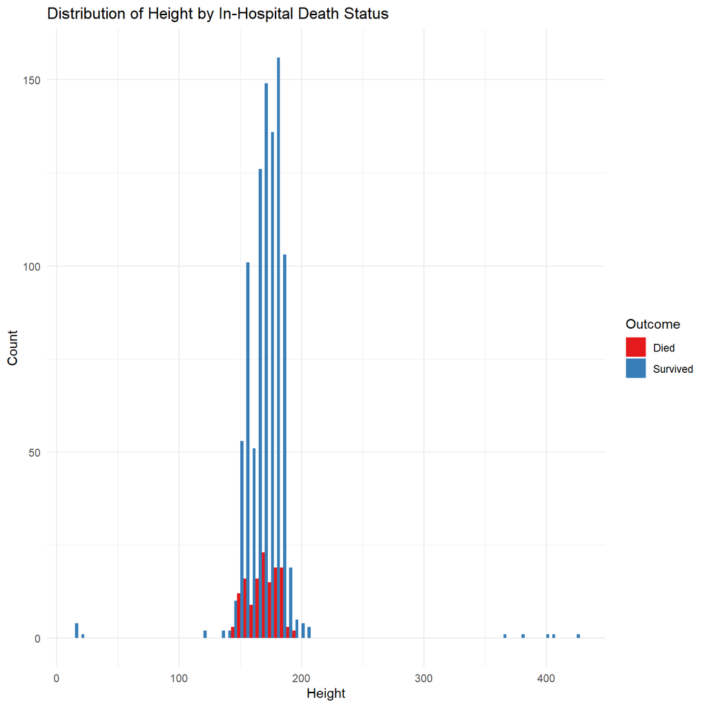

```r
print(plots[[2]]) # For Height
```

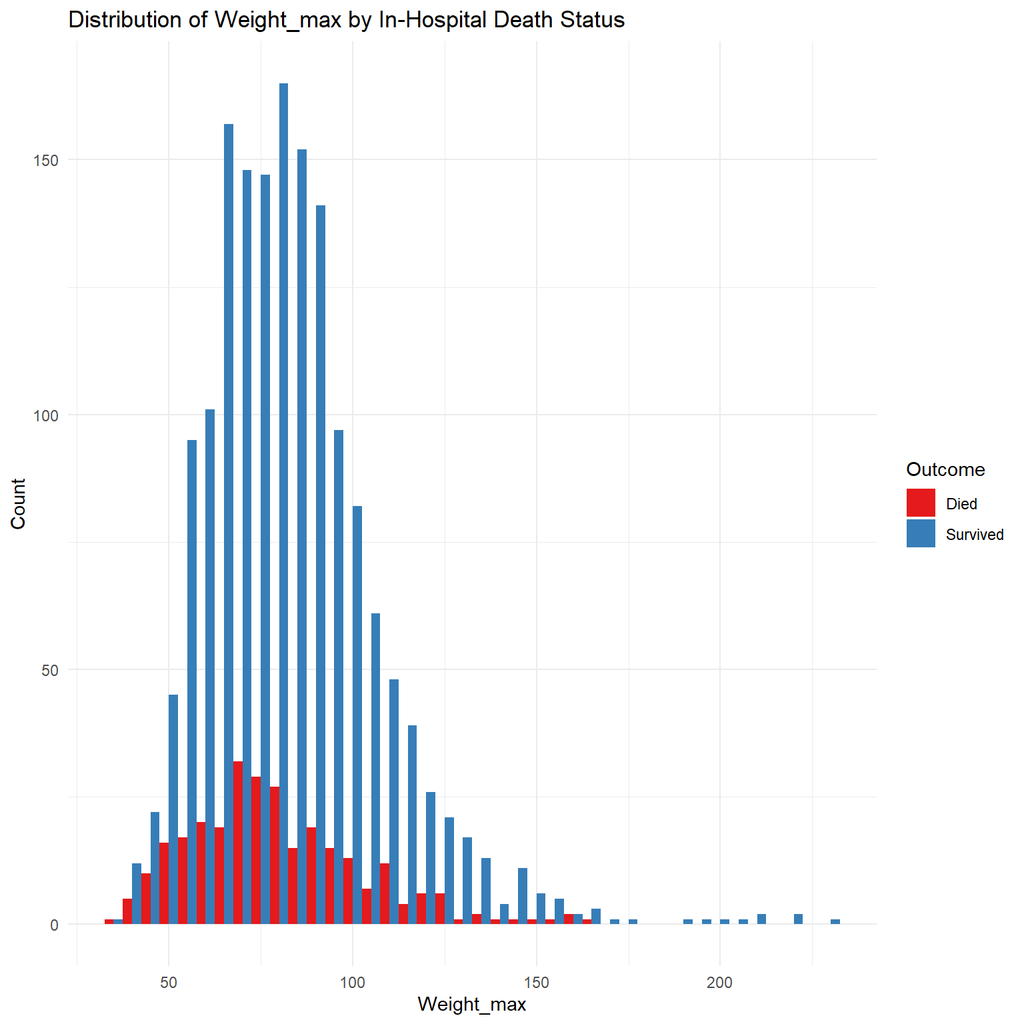

```r
print(plots[[3]]) # For Weight_max
```

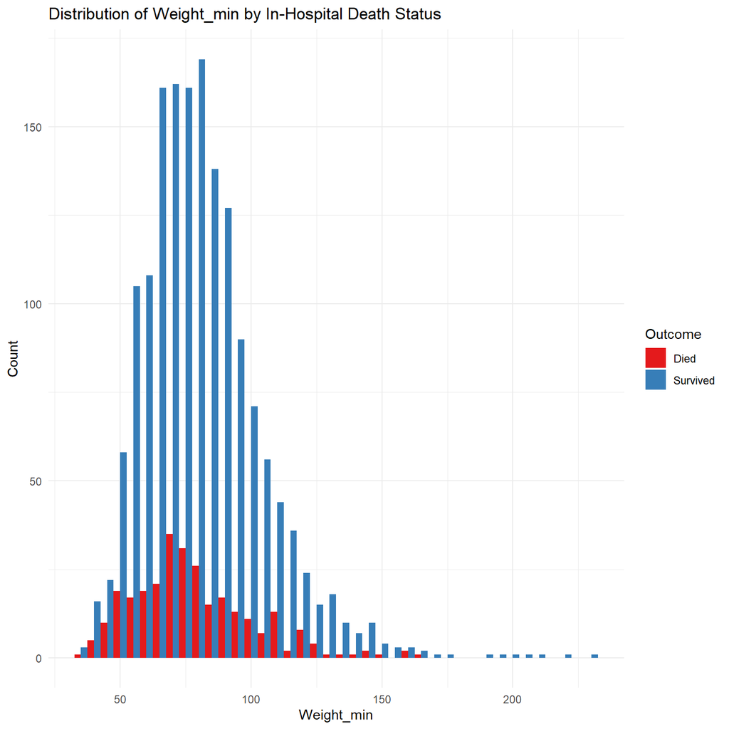

```r
print(plots[[4]]) # For Weight_min
```

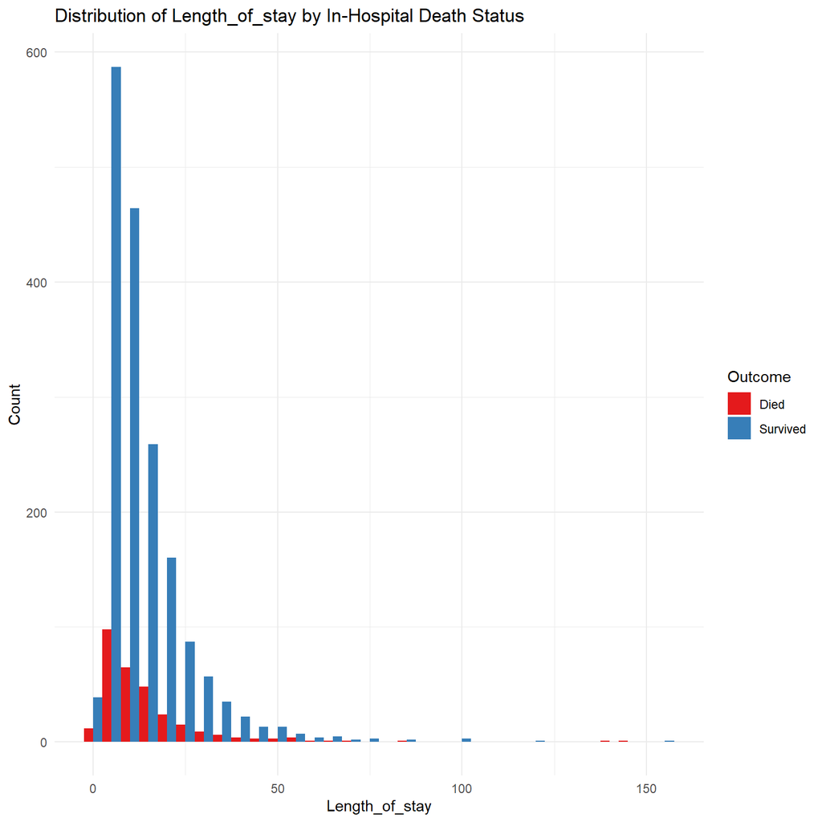

```r
print(plots[[5]]) # For Length_of_stay
```

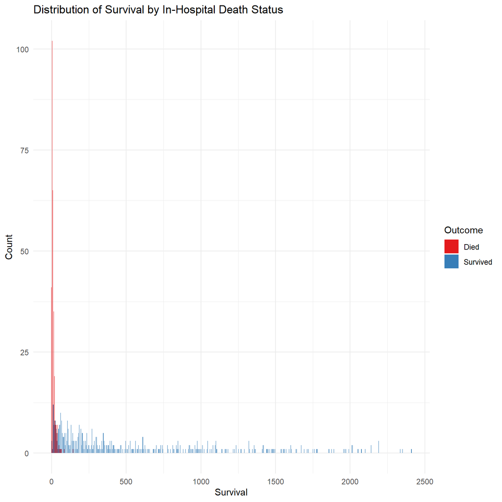

```r
print(plots[[6]]) # For Survival
```

For the `Height` which < 17.8 or > 365 should be error on data collection or recording

```r
# Correct the 'Height' variable by setting values outside the range 50 to 250 to NA
icu_patients_df1_h <- icu_patients_df1
icu_patients_df1_h$Height <- ifelse(icu_patients_df1_h$Height < 50 | icu_patients_df1_h$Height > 250, NA, icu_patients_df1_h$Height)

# Recheck the summary for Height in the new dataframe and reprint the plot
summary(icu_patients_df1_h$Height)
```

```
##    Min. 1st Qu.  Median    Mean 3rd Qu.    Max.    NA's
##   121.9   162.6   170.2   169.6   177.8   205.7    1002
```

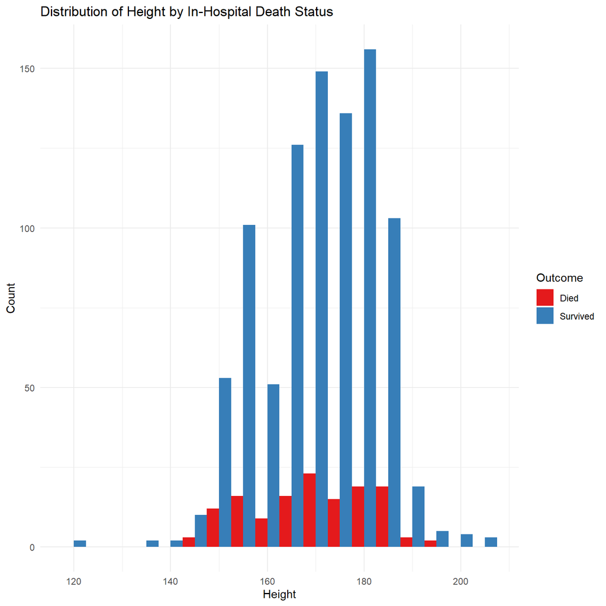

```r
plots2 <- lapply(demographic_vars, function(var) {
  ggplot(icu_patients_df1_h, aes_string(x = var, fill = "Status_Label")) +
    geom_histogram(position = "dodge", binwidth = 5, na.rm = TRUE) +
    labs(x = var, y = "Count") +
    scale_fill_brewer(palette = "Set1", name = "Outcome") +
    theme_minimal() +
    ggtitle(paste("Distribution of", var, "by In-Hospital Death Status"))
})

print(plots2[[2]])
```

**Histograms of the distribution of patient demographics** - Age Distribution: There is a noticeable increase in the count of younger patients who survived compared to those who did not, with survival rates decreasing as age increases. Particularly, the survival rate is significantly lower for patients aged above 70. - Height Distribution: The distribution of height shows a fairly normal range with most individuals between 150 and 200 cm. A few outliers below 150 cm may require verification for accuracy. The survival seems independent of height as both survived and died groups are similarly distributed. - Maximum & Minimum Weight Distribution: The weight of patients is concentrated around 50 to 100 kg. This indicates that extreme weights are not common among patients. The survival seems not too much dependent of the patient’s weight. - Length of Stay: The majority of patients had a shorter length of stay in the ICU. The survival seems independent of the number of days between the patient’s admission to the ICU and the end of hospitalisation as both survived and died groups are similarly distributed. - Survival Days: The survival days histogram is heavily skewed, with most patients surviving fewer days. The high number of patients with 0 survival days may indicate a significant number of deaths occurring shortly after admission to the ICU.

### Part B: Predictive logistic model

Your aim is to build a model to PREDICT in-hospital death. In this task, you are required to develop a logistic regression model using the `icu_patients_df1` data set which adequately **predicts** the `in_hospital_death` variable as the outcome and utilises predictor variables from your chosen subset. You should fit a series of models, evaluating each one, before you present your final model. Your final model should **not** include all the predictor variables, just a small selection of them, which you have selected based on statistical significance and/or background knowledge. Remember, your aim is prediction, but you should also consider generalisability of the model, so we are aiming for parsimony. Aim for between five and ten predictor variables (slightly more or fewer is OK). You should assess each model you consider for goodness of fit and other relevant statistics to help you choose between them. For your final model, present a set of relevant diagnostic statistics and/or charts and comment on them.

Finally, re-fit your final model to the unimputed data frame (`icu_patients_df0.rds`) and comment on any differences you find compared to the same model fitted to the imputed data.

**Create your response to task 1 here, as a mixture of embedded (`knitr`) R code and any resulting outputs, and explanatory or commentary text. Add code chunks as you see fit and choose whether you wish for the code and or results to be displayed in the final html document.**

```r
# Logistic regression to see the effect of SAPS1 and SOFA scores on in-hospital death
model_saps1 <- glm(in_hospital_death ~ SAPS1, data = icu_patients_df1_cleaned, family = binomial)
model_sofa <- glm(in_hospital_death ~ SOFA, data = icu_patients_df1_cleaned, family = binomial)

# Summary of logistic regression models
summary(model_saps1)
```

```
##
## Call:
## glm(formula = in_hospital_death ~ SAPS1, family = binomial, data = icu_patients_df1_cleaned)
##
## Coefficients:
##             Estimate Std. Error z value Pr(>|z|)
## (Intercept) -3.80084    0.23648 -16.073   <2e-16 ***
## SAPS1        0.12570    0.01333   9.428   <2e-16 ***
## ---
## Signif. codes:  0 '***' 0.001 '**' 0.01 '*' 0.05 '.' 0.1 ' ' 1
##
## (Dispersion parameter for binomial family taken to be 1)
##
##     Null deviance: 1699.7  on 2060  degrees of freedom
## Residual deviance: 1603.2  on 2059  degrees of freedom
## AIC: 1607.2
##
## Number of Fisher Scoring iterations: 5
```

```r
summary(model_sofa)
```

```
##
## Call:
## glm(formula = in_hospital_death ~ SOFA, family = binomial, data = icu_patients_df1_cleaned)
##
## Coefficients:
##             Estimate Std. Error z value Pr(>|z|)
## (Intercept) -2.88800    0.14713 -19.628   <2e-16 ***
## SOFA         0.14736    0.01601   9.207   <2e-16 ***
## ---
## Signif. codes:  0 '***' 0.001 '**' 0.01 '*' 0.05 '.' 0.1 ' ' 1
##
## (Dispersion parameter for binomial family taken to be 1)
##
##     Null deviance: 1699.7  on 2060  degrees of freedom
## Residual deviance: 1611.1  on 2059  degrees of freedom
## AIC: 1615.1
##
## Number of Fisher Scoring iterations: 5
```

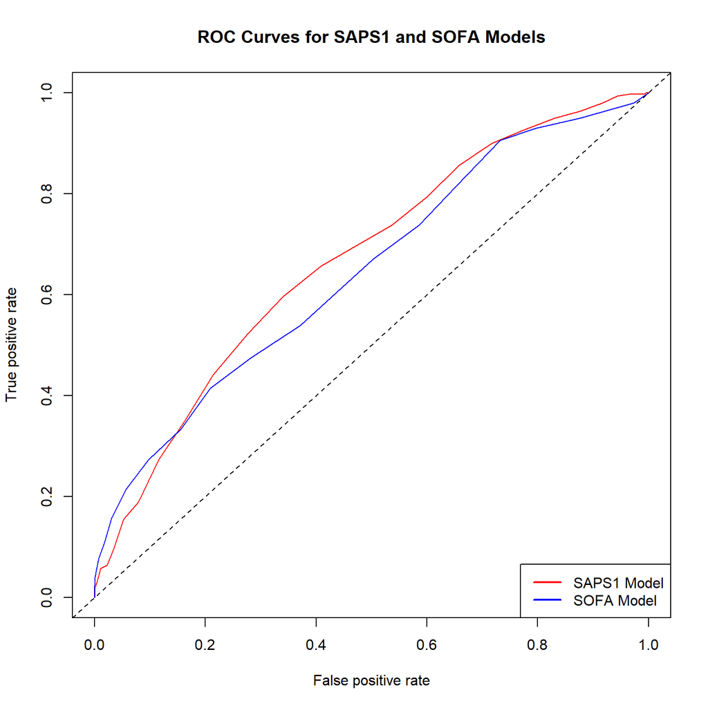

```r
# Predicted probabilities for the models
pred_saps1 <- predict(model_saps1, type = "response")
pred_sofa <- predict(model_sofa, type = "response")

# Create prediction objects for ROC analysis
pred_obj_saps1 <- prediction(pred_saps1, icu_patients_df1_cleaned$in_hospital_death)
pred_obj_sofa <- prediction(pred_sofa, icu_patients_df1_cleaned$in_hospital_death)

# Create performance objects for ROC analysis
perf_saps1 <- performance(pred_obj_saps1, "tpr", "fpr")
perf_sofa <- performance(pred_obj_sofa, "tpr", "fpr")

# Plot ROC curves
plot(perf_saps1, col = "red", main = "ROC Curves for SAPS1 and SOFA Models")
plot(perf_sofa, col = "blue", add = TRUE)
abline(a = 0, b = 1, lty = 2)

# Add a legend
legend("bottomright", legend = c("SAPS1 Model", "SOFA Model"), col = c("red", "blue"), lwd = 2)
```

```r
# Calculate AUC for SAPS1 model
auc_saps1 <- performance(pred_obj_saps1, measure = "auc")
auc_saps1_value <- auc_saps1@y.values[[1]]
cat("AUC for SAPS1 Model:", auc_saps1_value, "\n")
```

```
## AUC for SAPS1 Model: 0.6689533
```

```r
# Calculate AUC for SOFA model
auc_sofa <- performance(pred_obj_sofa, measure = "auc")
auc_sofa_value <- auc_sofa@y.values[[1]]
cat("AUC for SOFA Model:", auc_sofa_value, "\n")
```

```
## AUC for SOFA Model: 0.6453499
```

*Alternative variables* From the previous outputs and reference papers, here are some variables that be considered important for the Regression models: 1. **SAPS-I score**: The dataset includes SAPS1 as a variable, which is directly relevant 2. **SOFA score**: The dataset includes SOFA as a variable, also directly relevant 3. **Respiratory function**: PaO2, FiO2 and RespRate 4. **Coagulation & blood**: Platelets, pH, Glucose 5. **Liver function**: Bilirubin, Albumin, ALP, ALT, AST 6. **Cardiovascular system**: HR, MAP, TroponinI, TroponinT, Lactate 7. **Central nervous system**:GCS 8. **Renal function**: Creatinine, Urine 9. **immune system**: Temp, WBC 10.**Age**: Age

Building separate logistic regression models for each system (like respiratory, coagulation & blood, cardiovascular, etc.) can be a good approach to understand which variables within each system are most predictive of in-hospital death. Here’s a structured approach to building these models: 1. Respiratory Function Model: Use variables like PaO2_max, FiO2_max, and RespRate_max to reflect the most extreme states that may have critical implications for patient outcomes. 2. Coagulation & Blood Model: Platelets_max, pH_min, pH_max, and Glucose_max could be used to capture the most critical levels that may reflect acute events or stress responses. 3. Liver Function Model: Bilirubin_max, Albumin_min, ALP_max, ALT_max, and AST_max might be chosen to reflect liver function and injury. 4. Cardiovascular System Model: HR_max, MAP_max, TroponinI_max, and TroponinT_max, Lactate_max, Cholesterol_max can be indicators of cardiovascular stability and myocardial injury. 5. Central Nervous System Model: The GCS_min could be used as it represents the lowest level of consciousness. 6. Renal Function Model: Creatinine_max and Urine_min could be selected to reflect renal impairment or failure. 7. Immune System Model: Temp_max and WBC_max could reflect the highest levels of inflammatory response. 8. General Model: Incorporate variables like Age, Gender, weight, ICUType are broadly representative of patients’ status.

Once these models are built 1. Could compare them to determine which system’s variables are the strongest predictors. 2. Could build a combined model with the best predictors from each system.

```r
# Respiratory Function Model
resp_model <- glm(in_hospital_death ~ PaO2_max + FiO2_max + RespRate_max,
                  family = binomial(link = 'logit'), data = icu_patients_df1_cleaned)
summary(resp_model)
```

```
##
## Call:
## glm(formula = in_hospital_death ~ PaO2_max + FiO2_max + RespRate_max,
##     family = binomial(link = "logit"), data = icu_patients_df1_cleaned)
##
## Coefficients:
##                Estimate Std. Error z value Pr(>|z|)
## (Intercept)  -2.6154825  0.2998626  -8.722  < 2e-16 ***
## PaO2_max     -0.0020090  0.0005988  -3.355 0.000794 ***
## FiO2_max      0.2986832  0.2748118   1.087 0.277097
## RespRate_max  0.0344080  0.0075397   4.564 5.03e-06 ***
## ---
## Signif. codes:  0 '***' 0.001 '**' 0.01 '*' 0.05 '.' 0.1 ' ' 1
##
## (Dispersion parameter for binomial family taken to be 1)
##
##     Null deviance: 1699.7  on 2060  degrees of freedom
## Residual deviance: 1666.1  on 2057  degrees of freedom
## AIC: 1674.1
##
## Number of Fisher Scoring iterations: 4
```

```r
# Coagulation & Blood Model
coag_model <- glm(in_hospital_death ~ Platelets_max + pH_min + pH_max + Glucose_max,
                  family = binomial(link = 'logit'), data = icu_patients_df1_cleaned)
summary(coag_model)
```

```
##
## Call:
## glm(formula = in_hospital_death ~ Platelets_max + pH_min + pH_max +
##     Glucose_max, family = binomial(link = "logit"), data = icu_patients_df1_cleaned)
##
## Coefficients:
##                 Estimate Std. Error z value Pr(>|z|)
## (Intercept)   18.3259500  7.7186996   2.374 0.017586 *
## Platelets_max -0.0012617  0.0006031  -2.092 0.036433 *
## pH_min        -2.5456808  0.7066192  -3.603 0.000315 ***
## pH_max        -0.2083017  0.9912664  -0.210 0.833561
## Glucose_max    0.0020872  0.0005909   3.532 0.000412 ***
## ---
## Signif. codes:  0 '***' 0.001 '**' 0.01 '*' 0.05 '.' 0.1 ' ' 1
##
## (Dispersion parameter for binomial family taken to be 1)
##
##     Null deviance: 1699.7  on 2060  degrees of freedom
## Residual deviance: 1661.4  on 2056  degrees of freedom
## AIC: 1671.4
##
## Number of Fisher Scoring iterations: 4
```

```r
# Liver Function Model
liver_model <- glm(in_hospital_death ~ Bilirubin_max + Albumin_min + ALP_max + ALT_max + AST_max,
                  family = binomial(link = 'logit'), data = icu_patients_df1_cleaned)
summary(liver_model)
```

```
##
## Call:
## glm(formula = in_hospital_death ~ Bilirubin_max + Albumin_min +
##     ALP_max + ALT_max + AST_max, family = binomial(link = "logit"),
##     data = icu_patients_df1_cleaned)
##
## Coefficients:
##                 Estimate Std. Error z value Pr(>|z|)
## (Intercept)   -0.7763010  0.3203548  -2.423  0.01538 *
## Bilirubin_max  0.0466547  0.0118039   3.952 7.73e-05 ***
## Albumin_min   -0.4192390  0.1019020  -4.114 3.89e-05 ***
## ALP_max        0.0007561  0.0006333   1.194  0.23251
## ALT_max       -0.0006480  0.0003221  -2.012  0.04426 *
## AST_max        0.0006037  0.0002016   2.994  0.00275 **
## ---
## Signif. codes:  0 '***' 0.001 '**' 0.01 '*' 0.05 '.' 0.1 ' ' 1
##
## (Dispersion parameter for binomial family taken to be 1)
##
##     Null deviance: 1699.7  on 2060  degrees of freedom
## Residual deviance: 1636.7  on 2055  degrees of freedom
## AIC: 1648.7
##
## Number of Fisher Scoring iterations: 4
```

```r
# Cardiovascular System Model
cardio_model <- glm(in_hospital_death ~ HR_max + MAP_max + TroponinI_max + TroponinT_max + Lactate_max +Cholesterol_max,
                    family = binomial(link = 'logit'), data = icu_patients_df1_cleaned)
summary(cardio_model)
```

```
##
## Call:
## glm(formula = in_hospital_death ~ HR_max + MAP_max + TroponinI_max +
##     TroponinT_max + Lactate_max + Cholesterol_max, family = binomial(link = "logit"),
##     data = icu_patients_df1_cleaned)
##
## Coefficients:
##                   Estimate Std. Error z value Pr(>|z|)
## (Intercept)     -1.6297909  0.4239103  -3.845 0.000121 ***
## HR_max           0.0049931  0.0028614   1.745 0.080995 .
## MAP_max          0.0004522  0.0019161   0.236 0.813454
## TroponinI_max   -0.0062793  0.0059501  -1.055 0.291271
## TroponinT_max    0.0542017  0.0284773   1.903 0.056998 .
## Lactate_max      0.1403429  0.0272981   5.141 2.73e-07 ***
## Cholesterol_max -0.0076152  0.0016589  -4.591 4.42e-06 ***
## ---
## Signif. codes:  0 '***' 0.001 '**' 0.01 '*' 0.05 '.' 0.1 ' ' 1
##
## (Dispersion parameter for binomial family taken to be 1)
##
##     Null deviance: 1699.7  on 2060  degrees of freedom
## Residual deviance: 1641.2  on 2054  degrees of freedom
## AIC: 1655.2
##
## Number of Fisher Scoring iterations: 4
```

```r
# Central Nervous System Model
cns_model <- glm(in_hospital_death ~ GCS_min,
                 family = binomial(link = 'logit'), data = icu_patients_df1_cleaned)
summary(cns_model)
```

```
##
## Call:
## glm(formula = in_hospital_death ~ GCS_min, family = binomial(link = "logit"),
##     data = icu_patients_df1_cleaned)
##
## Coefficients:
##             Estimate Std. Error z value Pr(>|z|)
## (Intercept) -1.40261    0.12298 -11.405  < 2e-16 ***
## GCS_min     -0.04514    0.01317  -3.426 0.000612 ***
## ---
## Signif. codes:  0 '***' 0.001 '**' 0.01 '*' 0.05 '.' 0.1 ' ' 1
##
## (Dispersion parameter for binomial family taken to be 1)
##
##     Null deviance: 1699.7  on 2060  degrees of freedom
## Residual deviance: 1687.7  on 2059  degrees of freedom
## AIC: 1691.7
##
## Number of Fisher Scoring iterations: 4
```

```r
# Renal Function Model
renal_model <- glm(in_hospital_death ~ Creatinine_max + Urine_min,
                   family = binomial(link = 'logit'), data = icu_patients_df1_cleaned)
summary(renal_model)
```

```
##
## Call:
## glm(formula = in_hospital_death ~ Creatinine_max + Urine_min,
##     family = binomial(link = "logit"), data = icu_patients_df1_cleaned)
##
## Coefficients:
##                 Estimate Std. Error z value Pr(>|z|)
## (Intercept)    -1.884295   0.095766 -19.676  < 2e-16 ***
## Creatinine_max  0.157655   0.031742   4.967 6.81e-07 ***
## Urine_min      -0.005531   0.001732  -3.193  0.00141 **
## ---
## Signif. codes:  0 '***' 0.001 '**' 0.01 '*' 0.05 '.' 0.1 ' ' 1
##
## (Dispersion parameter for binomial family taken to be 1)
##
##     Null deviance: 1699.7  on 2060  degrees of freedom
## Residual deviance: 1660.0  on 2058  degrees of freedom
## AIC: 1666
##
## Number of Fisher Scoring iterations: 5
```

```r
# Immune System Model
immune_model <- glm(in_hospital_death ~ Temp_max + WBC_max,
                    family = binomial(link = 'logit'), data = icu_patients_df1_cleaned)
summary(immune_model)
```

```
##
## Call:
## glm(formula = in_hospital_death ~ Temp_max + WBC_max, family = binomial(link = "logit"),
##     data = icu_patients_df1_cleaned)
##
## Coefficients:
##              Estimate Std. Error z value Pr(>|z|)
## (Intercept)  1.881103   3.092064   0.608    0.543
## Temp_max    -0.102805   0.082261  -1.250    0.211
## WBC_max      0.014721   0.006865   2.144    0.032 *
## ---
## Signif. codes:  0 '***' 0.001 '**' 0.01 '*' 0.05 '.' 0.1 ' ' 1
##
## (Dispersion parameter for binomial family taken to be 1)
##
##     Null deviance: 1699.7  on 2060  degrees of freedom
## Residual deviance: 1694.1  on 2058  degrees of freedom
## AIC: 1700.1
##
## Number of Fisher Scoring iterations: 4
```

```r
# General Model
general_model <- glm(in_hospital_death ~ Age + Gender + Weight_max + ICUType,
                       family = binomial(link = 'logit'),
                       data = icu_patients_df1_h)
summary(general_model)
```

```
##
## Call:
## glm(formula = in_hospital_death ~ Age + Gender + Weight_max +
##     ICUType, family = binomial(link = "logit"), data = icu_patients_df1_h)
##
## Coefficients:
##                                        Estimate Std. Error z value Pr(>|z|)
## (Intercept)                          -4.0772069  0.4857020  -8.394  < 2e-16 ***
## Age                                   0.0328361  0.0045562   7.207 5.72e-13 ***
## GenderMale                            0.1026777  0.1387050   0.740   0.4591
## Weight_max                            0.0002256  0.0030495   0.074   0.9410
## ICUTypeCardiac Surgery Recovery Unit -1.0938298  0.2655173  -4.120 3.80e-05 ***
## ICUTypeMedical ICU                    0.4044202  0.1931902   2.093   0.0363 *
## ICUTypeSurgical ICU                   0.1510145  0.2104912   0.717   0.4731
## ---
## Signif. codes:  0 '***' 0.001 '**' 0.01 '*' 0.05 '.' 0.1 ' ' 1
##
## (Dispersion parameter for binomial family taken to be 1)
##
##     Null deviance: 1604.2  on 1914  degrees of freedom
## Residual deviance: 1493.4  on 1908  degrees of freedom
##   (因为不存在，146个观察量被删除了)
## AIC: 1507.4
##
## Number of Fisher Scoring iterations: 5
```

*model summaries:* 1. In the Respiratory Function Model, PaO2_max and RespRate_max are significant predictors. FiO2_max is not statistically significant, which means it might not be a strong predictor for the outcome in this model. 2. For the Coagulation & Blood Model, pH_min and Glucose_max are significant, while pH_max is not. This suggests that low blood pH (Acidosis ) and glucose levels could be important predictors for in-hospital death. 3. For liver function model, except ALP_max all other biochemical markers are significant. Bilirubin_max and Albumin_min being particularly strong predictors. 4. The Cardiovascular System Model shows that Lactate_max and Cholesterol_max have a significant relationship with the outcome. HR_max, MAP_max, TroponinI_max, and TroponinT_max did not reach statistical significance, although TroponinT_max is close and could be considered for inclusion in a more comprehensive model. 5. In the Central Nervous System Model, GCS_min is a significant predictor. This aligns with medical knowledge, as a lower Glasgow Coma Score is associated with higher severity of disease. 6. For the Renal Function Model, both Creatinine_max and Urine_min are significant. This suggests that worse renal function is associated with a higher risk of in-hospital death. 7. The Immune System Model indicates that WBC_max is significant, but Temp_max is not. This could suggest that a higher white blood cell count, which might indicate infection or inflammation, is more predictive of in-hospital death than the maximum temperature. 8. Finally, the Demographics Model with Age, Gender, Weight, and ICUType shows that Age and ICUType (specifically, the Cardiac Surgery Recovery Unit and Medical ICU) are significant predictors. Gender and Weight_max do not appear to contribute significantly to this model.

Based on observations, a model aiming for parsimony and generalizability could include the following variables: Age Albumin_max Bilirubin_max BUN_max Cholesterol_max Creatinine_max GCS_max GCS_min Glucose_max HR_diff Lactate_max Na_diff NISysABP_diff PaO2_max pH_diff pH_min RespRate_max Temp_diff Urine_max Urine_min WBC_max

Base on `Estimate` values we could try three different style models

Research has demonstrated that elevated levels of Albumin, AST, Bilirubin, BUN, Creatinine, GCS, Glucose, HCO3, Lactate, respiratory rate and urine output are significant indicators of survival outcome in an ICU. Hence, the maximum variables of these clinical measures may be potential predictors. On the other hand, sudden large changes in heart rate, sodium, pH, temperature and non-invasive systolic blood pressure have been found to have a strong association with ICU survival outcomes. Hence, the difference values of these variables may be more suitable as predictors.

```r
# Significant Maximum Levels Model (focusing on variables identified as critical)
max_levels_model <- glm(in_hospital_death ~ Albumin_max + AST_max + Bilirubin_max + BUN_max + Creatinine_max + GCS_max + Glucose_max + HCO3_max + Lactate_max + RespRate_max + Urine_max,
                        family = binomial(link = 'logit'), data = icu_patients_df1_cleaned)
summary(max_levels_model)
```

```
##
## Call:
## glm(formula = in_hospital_death ~ Albumin_max + AST_max + Bilirubin_max +
##     BUN_max + Creatinine_max + GCS_max + Glucose_max + HCO3_max +
##     Lactate_max + RespRate_max + Urine_max, family = binomial(link = "logit"),
##     data = icu_patients_df1_cleaned)
##
## Coefficients:
##                  Estimate Std. Error z value Pr(>|z|)
## (Intercept)     9.477e-01  6.667e-01   1.421  0.15522
## Albumin_max    -3.051e-01  1.134e-01  -2.690  0.00715 **
## AST_max         1.372e-04  7.786e-05   1.762  0.07807 .
## Bilirubin_max   3.919e-02  1.315e-02   2.981  0.00288 **
## BUN_max         2.444e-02  3.555e-03   6.876 6.17e-12 ***
## Creatinine_max -1.417e-01  5.355e-02  -2.645  0.00817 **
## GCS_max        -1.653e-01  2.122e-02  -7.788 6.79e-15 ***
## Glucose_max     9.886e-04  7.002e-04   1.412  0.15800
## HCO3_max       -1.864e-02  1.610e-02  -1.157  0.24712
## Lactate_max     4.770e-02  3.079e-02   1.549  0.12132
## RespRate_max    4.565e-03  8.950e-03   0.510  0.61002
## Urine_max      -1.029e-03  2.099e-04  -4.902 9.50e-07 ***
## ---
## Signif. codes:  0 '***' 0.001 '**' 0.01 '*' 0.05 '.' 0.1 ' ' 1
##
## (Dispersion parameter for binomial family taken to be 1)
##
##     Null deviance: 1699.7  on 2060  degrees of freedom
## Residual deviance: 1442.0  on 2049  degrees of freedom
## AIC: 1466
##
## Number of Fisher Scoring iterations: 5
```

```r
# Significant Difference Levels Model (focusing on variables where changes were noted as important)
diff_levels_model <- glm(in_hospital_death ~ HR_diff + Na_diff + pH_diff + Temp_diff + NISysABP_diff,
                         family = binomial(link = 'logit'), data = icu_patients_df1_cleaned)
summary(diff_levels_model)
```

```
##
## Call:
## glm(formula = in_hospital_death ~ HR_diff + Na_diff + pH_diff +
##     Temp_diff + NISysABP_diff, family = binomial(link = "logit"),
##     data = icu_patients_df1_cleaned)
##
## Coefficients:
##                Estimate Std. Error z value Pr(>|z|)
## (Intercept)   -3.708414   0.233460 -15.885  < 2e-16 ***
## HR_diff        0.012204   0.003714   3.286 0.001017 **
## Na_diff        0.054231   0.015055   3.602 0.000316 ***
## pH_diff        3.856638   0.939342   4.106 4.03e-05 ***
## Temp_diff      0.234241   0.081195   2.885 0.003915 **
## NISysABP_diff  0.014426   0.003351   4.306 1.67e-05 ***
## ---
## Signif. codes:  0 '***' 0.001 '**' 0.01 '*' 0.05 '.' 0.1 ' ' 1
##
## (Dispersion parameter for binomial family taken to be 1)
##
##     Null deviance: 1699.7  on 2060  degrees of freedom
## Residual deviance: 1608.9  on 2055  degrees of freedom
## AIC: 1620.9
##
## Number of Fisher Scoring iterations: 5
```

```r
# Combined Model incorporating both max and difference values of selected indicators
combined_model <- glm(in_hospital_death ~ Albumin_max + AST_max + Bilirubin_max + BUN_max + Creatinine_max + GCS_max + Glucose_max + HCO3_max + Lactate_max + RespRate_max + Urine_max + HR_diff + Na_diff + pH_diff + Temp_diff + NISysABP_diff + Age + Gender + Weight_max,
                      family = binomial(link = 'logit'), data = icu_patients_df1_cleaned)
summary(combined_model)
```

```
##
## Call:
## glm(formula = in_hospital_death ~ Albumin_max + AST_max + Bilirubin_max +
##     BUN_max + Creatinine_max + GCS_max + Glucose_max + HCO3_max +
##     Lactate_max + RespRate_max + Urine_max + HR_diff + Na_diff +
##     pH_diff + Temp_diff + NISysABP_diff + Age + Gender + Weight_max,
##     family = binomial(link = "logit"), data = icu_patients_df1_cleaned)
##
## Coefficients:
##                  Estimate Std. Error z value Pr(>|z|)
## (Intercept)    -1.665e+00  8.602e-01  -1.935 0.052954 .
## Albumin_max    -3.452e-01  1.174e-01  -2.939 0.003291 **
## AST_max         1.924e-04  8.547e-05   2.251 0.024389 *
## Bilirubin_max   5.021e-02  1.327e-02   3.784 0.000155 ***
## BUN_max         1.886e-02  3.693e-03   5.108 3.25e-07 ***
## Creatinine_max -7.960e-02  5.457e-02  -1.459 0.144619
## GCS_max        -1.594e-01  2.216e-02  -7.193 6.33e-13 ***
## Glucose_max     6.685e-04  7.569e-04   0.883 0.377152
## HCO3_max       -1.789e-02  1.651e-02  -1.083 0.278701
## Lactate_max     1.397e-03  3.433e-02   0.041 0.967545
## RespRate_max    3.515e-03  9.341e-03   0.376 0.706650
## Urine_max      -8.896e-04  2.083e-04  -4.270 1.96e-05 ***
## HR_diff         1.028e-02  4.086e-03   2.517 0.011828 *
## Na_diff         2.214e-02  1.850e-02   1.197 0.231453
## pH_diff         2.504e+00  1.135e+00   2.207 0.027294 *
## Temp_diff       1.425e-01  9.053e-02   1.574 0.115476
## NISysABP_diff   9.901e-03  3.812e-03   2.597 0.009400 **
## Age             2.744e-02  4.935e-03   5.561 2.69e-08 ***
## GenderMale      5.097e-03  1.464e-01   0.035 0.972221
## Weight_max     -3.701e-03  3.424e-03  -1.081 0.279662
## ---
## Signif. codes:  0 '***' 0.001 '**' 0.01 '*' 0.05 '.' 0.1 ' ' 1
##
## (Dispersion parameter for binomial family taken to be 1)
##
##     Null deviance: 1699.7  on 2060  degrees of freedom
## Residual deviance: 1372.7  on 2041  degrees of freedom
## AIC: 1412.7
##
## Number of Fisher Scoring iterations: 6
```

```r
#vars_needed <- c("Age", "SAPS1", "SOFA", "Albumin_max", "ALT_max", "AST_max", "Bilirubin_max", "BUN_max",
#                 "Cholesterol_max", "Creatinine_max", "GCS_max", "GCS_min", "Glucose_max", "HR_diff",
#                 "Lactate_max", "Na_diff", "NISysABP_diff", "PaO2_max", "pH_diff", "pH_min", "RespRate_max",
#                 "Temp_diff", "Urine_max", "Urine_min", "WBC_max", "ICUType", "in_hospital_death") # Add all other variables involved in both models

#consistent_data <- icu_patients_df1[complete.cases(icu_patients_df1[, vars_needed]), ]

# Creating intact model with all significant predictors
intact_model <- glm(in_hospital_death ~ Age + SAPS1 + SOFA + Albumin_max + ALT_max + AST_max + Bilirubin_max + BUN_max + Cholesterol_max +
                        Creatinine_max + GCS_max + GCS_min + Glucose_max + HR_diff + Lactate_max + Na_diff +
                        NISysABP_diff + PaO2_max + pH_diff + pH_min + RespRate_max + Temp_diff + Urine_max +
                        Urine_min + WBC_max + ICUType,
                    family = binomial(link = "logit"), data = icu_patients_df1_cleaned)
summary(intact_model)
```

```
##
## Call:
## glm(formula = in_hospital_death ~ Age + SAPS1 + SOFA + Albumin_max +
##     ALT_max + AST_max + Bilirubin_max + BUN_max + Cholesterol_max +
##     Creatinine_max + GCS_max + GCS_min + Glucose_max + HR_diff +
##     Lactate_max + Na_diff + NISysABP_diff + PaO2_max + pH_diff +
##     pH_min + RespRate_max + Temp_diff + Urine_max + Urine_min +
##     WBC_max + ICUType, family = binomial(link = "logit"), data = icu_patients_df1_cleaned)
##
## Coefficients:
##                                        Estimate Std. Error z value Pr(>|z|)
## (Intercept)                           0.0164869  7.9167297   0.002 0.998338
## Age                                   0.0248098  0.0054517   4.551 5.34e-06 ***
## SAPS1                                 0.0479217  0.0256290   1.870 0.061508 .
## SOFA                                  0.0542964  0.0288910   1.879 0.060197 .
## Albumin_max                          -0.2207325  0.1247121  -1.770 0.076738 .
## ALT_max                              -0.0010265  0.0004560  -2.251 0.024394 *
## AST_max                               0.0007422  0.0002760   2.689 0.007159 **
## Bilirubin_max                         0.0441906  0.0141351   3.126 0.001770 **
## BUN_max                               0.0151427  0.0039018   3.881 0.000104 ***
## Cholesterol_max                      -0.0028892  0.0021848  -1.322 0.186032
## Creatinine_max                       -0.1098293  0.0549164  -2.000 0.045507 *
## GCS_max                              -0.1757922  0.0303920  -5.784 7.29e-09 ***
## GCS_min                               0.0573900  0.0289728   1.981 0.047611 *
## Glucose_max                           0.0002731  0.0008164   0.335 0.737943
## HR_diff                               0.0076404  0.0043728   1.747 0.080590 .
## Lactate_max                           0.0072310  0.0365558   0.198 0.843196
## Na_diff                               0.0173701  0.0193868   0.896 0.370266
## NISysABP_diff                         0.0077138  0.0039997   1.929 0.053780 .
## PaO2_max                             -0.0019202  0.0008011  -2.397 0.016529 *
## pH_diff                               2.5020583  1.4083357   1.777 0.075633 .
## pH_min                               -0.3332980  1.0332017  -0.323 0.747008
## RespRate_max                          0.0037918  0.0098111   0.386 0.699138
## Temp_diff                             0.0820163  0.0983564   0.834 0.404355
## Urine_max                            -0.0007298  0.0002151  -3.393 0.000692 ***
## Urine_min                            -0.0019255  0.0018548  -1.038 0.299206
## WBC_max                              -0.0091427  0.0086483  -1.057 0.290434
## ICUTypeCardiac Surgery Recovery Unit -0.6354553  0.3242303  -1.960 0.050009 .
## ICUTypeMedical ICU                   -0.1043047  0.2136477  -0.488 0.625402
## ICUTypeSurgical ICU                   0.0099559  0.2359503   0.042 0.966343
## ---
## Signif. codes:  0 '***' 0.001 '**' 0.01 '*' 0.05 '.' 0.1 ' ' 1
##
## (Dispersion parameter for binomial family taken to be 1)
##
##     Null deviance: 1699.7  on 2060  degrees of freedom
## Residual deviance: 1338.2  on 2032  degrees of freedom
## AIC: 1396.2
##
## Number of Fisher Scoring iterations: 6
```

```r
# Using stepwise regression to find an optimal set of predictors for intact model
stepwise_result <- stepAIC(intact_model, direction = "both", trace = FALSE) #stepwise_result2 <- stats::step(intact_model,direction="both", trace=0)
summary(stepwise_result)
```

```
##
## Call:
## glm(formula = in_hospital_death ~ Age + SAPS1 + SOFA + Albumin_max +
##     ALT_max + AST_max + Bilirubin_max + BUN_max + Creatinine_max +
##     GCS_max + GCS_min + HR_diff + NISysABP_diff + PaO2_max +
##     pH_diff + Urine_max + ICUType, family = binomial(link = "logit"),
##     data = icu_patients_df1_cleaned)
##
## Coefficients:
##                                        Estimate Std. Error z value Pr(>|z|)
## (Intercept)                          -2.9586700  0.7516403  -3.936 8.28e-05 ***
## Age                                   0.0261907  0.0052084   5.029 4.94e-07 ***
## SAPS1                                 0.0580310  0.0230064   2.522 0.011656 *
## SOFA                                  0.0583371  0.0280534   2.079 0.037572 *
## Albumin_max                          -0.2497119  0.1199924  -2.081 0.037428 *
## ALT_max                              -0.0010521  0.0004431  -2.375 0.017571 *
## AST_max                               0.0007670  0.0002632   2.914 0.003570 **
## Bilirubin_max                         0.0463521  0.0135900   3.411 0.000648 ***
## BUN_max                               0.0154032  0.0037981   4.055 5.00e-05 ***
## Creatinine_max                       -0.1037505  0.0541855  -1.915 0.055527 .
## GCS_max                              -0.1708445  0.0275421  -6.203 5.54e-10 ***
## GCS_min                               0.0546851  0.0282780   1.934 0.053133 .
## HR_diff                               0.0078886  0.0043060   1.832 0.066948 .
## NISysABP_diff                         0.0075894  0.0039740   1.910 0.056160 .
## PaO2_max                             -0.0018209  0.0007904  -2.304 0.021244 *
## pH_diff                               2.5952276  1.1409727   2.275 0.022931 *
## Urine_max                            -0.0007388  0.0002126  -3.475 0.000511 ***
## ICUTypeCardiac Surgery Recovery Unit -0.7094156  0.3114644  -2.278 0.022746 *
## ICUTypeMedical ICU                   -0.0874038  0.2103697  -0.415 0.677793
## ICUTypeSurgical ICU                   0.0258841  0.2331446   0.111 0.911599
## ---
## Signif. codes:  0 '***' 0.001 '**' 0.01 '*' 0.05 '.' 0.1 ' ' 1
##
## (Dispersion parameter for binomial family taken to be 1)
##
##     Null deviance: 1699.7  on 2060  degrees of freedom
## Residual deviance: 1344.0  on 2041  degrees of freedom
## AIC: 1384
##
## Number of Fisher Scoring iterations: 6
```

```r
# Variance Inflation Factor (VIF) check
vif_values <- vif(intact_model, type = 'terms')
print(vif_values)
```

```
##                      GVIF Df GVIF^(1/(2*Df))
## Age              1.424504  1        1.193526
## SAPS1            2.897716  1        1.702268
## SOFA             2.777311  1        1.666527
## Albumin_max      1.154386  1        1.074424
## ALT_max         10.538677  1        3.246333
## AST_max         10.829452  1        3.290813
## Bilirubin_max    1.181173  1        1.086818
## BUN_max          2.211248  1        1.487027
## Cholesterol_max  1.640938  1        1.280991
## Creatinine_max   2.054436  1        1.433330
## GCS_max          2.233864  1        1.494612
## GCS_min          3.591989  1        1.895254
## Glucose_max      1.283392  1        1.132869
## HR_diff          1.184397  1        1.088300
## Lactate_max      1.567846  1        1.252137
## Na_diff          1.190584  1        1.091139
## NISysABP_diff    1.147000  1        1.070981
## PaO2_max         1.554490  1        1.246792
## pH_diff          1.830825  1        1.353080
## pH_min           2.068455  1        1.438212
## RespRate_max     1.322456  1        1.149981
## Temp_diff        1.297283  1        1.138983
## Urine_max        1.169846  1        1.081594
## Urine_min        1.126448  1        1.061343
## WBC_max          1.187742  1        1.089836
## ICUType          1.881888  3        1.111132
```